# 21020

Ruoxuan Li

2021-12-20

—————————2021-09-23————————————  
## Question

Exercises 3.4 3.11 3.20

## Answer

3.4:利用Inverse transformation method产生随机数，分别设置sigma为1,3,7,10进行比较。

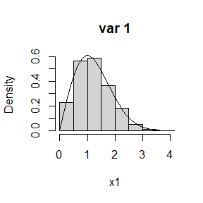

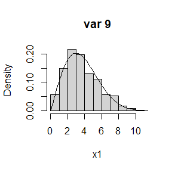

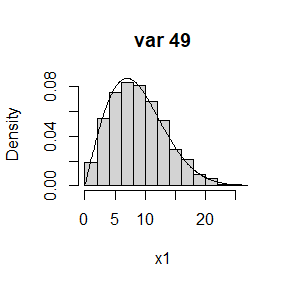

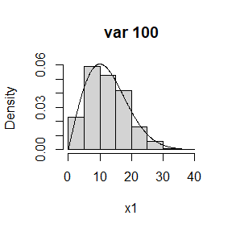

```r
Var=c(1,9,49,100)
for(i in Var){
  n<-1000
  u<-runif(n)
  x1<-sqrt(2*i*log(1/(1-u)))
  hist(x1,prob=TRUE,main=paste("var",i))
  y<-seq(0,40,0.1)
  lines(y,y*exp(-y^2/(2*i))/i)
}
```

3.11:分别设置p1为0.25,0.4,0.5,0.75生成混合分布的随机数，可以看出p1为0.4和0.5时，分布为双峰分布。

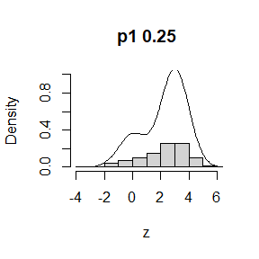

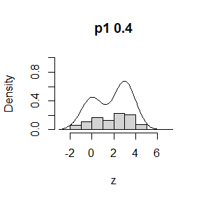

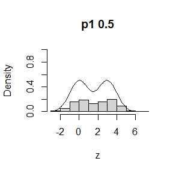

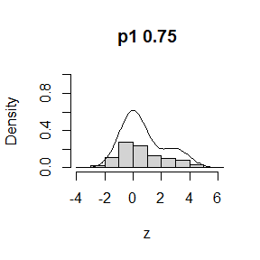

```r
p1=c(0.25,0.4,0.5,0.75)
for(j in p1){
m<-1000
r1<-rnorm(m)
r2<-rnorm(m,3,1)
o<-sample(c(0,1),m,replace=TRUE,prob=c(1-j,j))
z<-o*r1+(1-o)*r2
hist(z,prob=TRUE,ylim=c(0,1),main=paste("p1",j))
y0<-seq(-3,8,0.1)
lines(y0,(j*exp(-y0^2/2)+(1-j)*exp(-(y0-3)^2/2))/sqrt(2*j))
}
```

3.20:分布取lamda为1,3,5进行模拟对比。

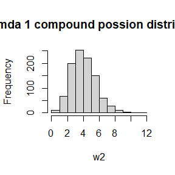

```
## lamda 1 Distributed sample mean: 4.022895
## lamda 1 True sample mean: 4
## lamda 1 Distributed sample mean: 2.408786
## lamda 1 True sample mean: 2.4
```

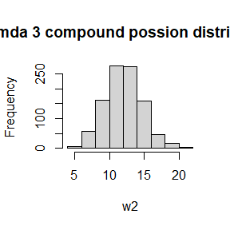

```
## lamda 3 Distributed sample mean: 12.05927
## lamda 3 True sample mean: 12
## lamda 3 Distributed sample mean: 7.078782
## lamda 3 True sample mean: 7.2
```

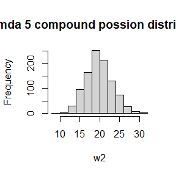

```
## lamda 5 Distributed sample mean: 19.7792
## lamda 5 True sample mean: 20
## lamda 5 Distributed sample mean: 11.43788
## lamda 5 True sample mean: 12
```

```r
lamda<-c(1,3,5)
for(l in lamda){
q<-1000
t<-10
r<-2
beta<-5
w1<-rpois(q,l*t)
w2<-rgamma(q,r*w1,beta)
hist(w2,main=paste("lamda",l,"compound possion distribution"))
wmean<-mean(w2)
tmean<-l*t*r/beta
wvar<-var(w2)
tvar<-l*t*r*(r+1)/beta^2
cat("lamda",l,"Distributed sample mean:",wmean,"\n")
cat("lamda",l,"True sample mean:",tmean,"\n")
cat("lamda",l,"Distributed sample mean:",wvar,"\n")
cat("lamda",l,"True sample mean:",tvar,"\n")
}
```

可以看出，样本分布和真实分布的均值和方差非常接近。  
Note that the `echo = FALSE` parameter was added to the code chunk to prevent printing of the R code that generated the plot.  
—————————2021-09-30———————————–  
##Question  
Exercises 5.4, 5.9, 5.13, and 5.14 (pages 149-151, Statistical Computating with R).

##Answer
5.4
假设随机变量$X$服从$Beta(3,3)$,当$x$属于$(0,1)$时，$X$的密度函数为
$$p(x)=30x^2(1-x)^2,0<x<1$$
分布函数可以表示为
$$F(x)=\int_{0}^{x}30(t^2-2t^3+t^4)dt\\=\int_{0}^{x}30x(t^2-2t^3+t^4)\frac{1}{x}dt\\=E(30x(T^2-2T^3+T^4))$$
其中，$T$服从$U(0,x)$.

```r
set.seed(1234)

beta33<-function(x,alpha=3,beta=3){
  n<-10000
  t<-runif(n,min=0,max=x)
  x0<-30*x*(t^2-2*t^3+t^4)
  return(mean(x0))
}
x1<-seq(0.1,0.9,0.1)
y<-numeric(9)
j<-1
for(i in x1){
  y[j]=beta33(i)
  j<-j+1
}

y0<-numeric(9)
k<-1
for(i in x1){
  y0[k]<-pbeta(i,3,3)
  k<-k+1
}


table1=cbind(x1,y,y0)
knitr::kable(table1,align='c',col.names =c('x','simulation','true'))
```

| x | simulation | true |
| --- | --- | --- |
| 0.1 | 0.0085474 | 0.00856 |
| 0.2 | 0.0585408 | 0.05792 |
| 0.3 | 0.1650280 | 0.16308 |
| 0.4 | 0.3119241 | 0.31744 |
| 0.5 | 0.4995373 | 0.50000 |
| 0.6 | 0.6805351 | 0.68256 |
| 0.7 | 0.8427222 | 0.83692 |
| 0.8 | 0.9473116 | 0.94208 |
| 0.9 | 0.9971875 | 0.99144 |

可以看出，模拟值和真实值十分接近，模拟效果很好。
5.9
Rayleigh密度函数为
$$f(x)=\frac{x}{σ^2}e^{-x^2/(2σ^2)} , x≥0 , σ>0$$
其分布函数为
$$F(x)=\int_{0}^{x}\frac{t}{σ^2}e^{-t^2/(2σ^2)}dt\\\int_{0}^{x}x\frac{t}{σ^2}e^{-t^2/(2σ^2)}\frac{1}{x}dt\\=E(x\frac{T}{σ^2}e^{-T^2/(2σ^2)})$$
其中，$T$服从$U(0,x)$,分别采用对偶变量$T$,$x-T$和相互独立变量$T$,$V$进行拟合，最后进行比较。

```r
set.seed(1234)
Rayleign<-function(x,sigma,N=10000,anti=TRUE){
  u<-runif(N/2,min=0,max=x)
  if (!anti) v <- runif(N/2,min=0,max=x) else v <- x - u
  u<-c(u,v)
  y<-x*u*exp(-u^2/2/(sigma^2))/(sigma^2)
  return(mean(y))
}

x<-c(1.5,3,10,20)
sigma<-2
y2<-numeric(length(x))
y3<-numeric(length(x))
sd1<-numeric(length(x))
sd2<-numeric(length(x))
mean1<-numeric(length(x))
mean2<-numeric(length(x))
for(k in 1:length(x)){
  for(i in 1:1000){
    y2[i]<-Rayleign(x[k],sigma,anti=TRUE)
    y3[i]<-Rayleign(x[k],sigma,anti=FALSE)
  }
 mean1[k]<-mean(y2)
 mean2[k]<-mean(y3)
 sd1[k]<-sd(y2)
 sd2[k]<-sd(y3)
}

percent=sd2/sd1

table2<-cbind(x,sigma,mean1,sd1,mean2,sd2,percent)
knitr::kable(table2,align='c',col.names =c('x','sigma',"Mean value of simulated value of dual variable","Standard deviation of simulated value of dual variable","Mean of simulated values of independent variables","Standard deviation of simulated value of independent variable","Percentage reduction in standard deviation"))
```

[output not shown]

## QUESTIONS:

1.Exercises 6.5 and 6.A (page 180-181, Statistical Computating with R).  
2.If we obtain the powers for two methods under a particular simulation setting with 10,000 experiments: say, 0.651 for one method and 0.676 for another method. We want to know if the powers are different at 0.05 level.  
(1)What is the corresponding hypothesis test problem?  
(2)What test should we use? Z-test, two-sample t-test, paired-t test or McNemar test? Why?  
(3)Please provide the least necessary information for hypothesis testing.

## ANSWERS:

6.5:Suppose a 95% symmetric t-interval is applied to estimate a mean, but the sample data are non-normal. Then the probability that the confidence interval covers the mean is not necessarily equal to 0.95. Use a Monte Carlo experiment to estimate the coverage probability of the t-interval for random samples of$\chi^2(2)$ data with sample size n = 20. Compare your t-interval results with the simulation results in Example 6.4. (The t-interval should be more robust to departures from normality than the interval for variance.)
分析：进行1000次试验，每次试验产生20个服从$\chi^2(2)$的随机数，计算$\bar\mu$和$\hat\sigma$,真实均值的t-interval为
$$(\bar\mu-\frac{1}{\sqrt(n)}t_{0.975}(n-1)\hat\sigma,\bar\mu+\frac{1}{\sqrt(n)}t_{0.025}(n-1)\hat\sigma)$$
判断真实均值2是否在t-interval中，若在则用y表示为1否则为0，最后计算所有试验的y的均值则可得Coverage probability.

```r
set.seed(123)
m<-1000
n<-20
u<-sigma<-y<-numeric(m)
for(i in 1:m){
   x<-rchisq(n,df=2)
   u[i]<-mean(x)
   sigma[i]<-sd(x)
   y[i]<-(2<=u[i]-qt(0.025,n-1)*sigma[i]/sqrt(n)&2>=u[i]-qt(0.975,n-1)*sigma[i]/sqrt(n))
}
cp1<-round(mean(y),3)
```

得出Coverage Probability为0.908，小于0.95，该t-interval是liberal的。  
与Example 6.4进行对比：假设在Example 6.4中，$X_1,X_2,…，X_n$也服从$\chi^2(2)$，按原方式计算方差的置信区间，算出Coverage Probability,与t-interval的Coverage Probability进行比较，看谁更稳健。

```r
set.seed(123)
m<-1000
n<-20
UCL<-y<-numeric(m)
for(i in 1:m){
  x<-rchisq(n,df=2)
  UCL[i]<-(n-1)*var(x)/qchisq(0.05,df=n-1)
  y[i]<-(4<=UCL[i])
}
cp2<-round(mean(y),3)
```

根据Example 6.4计算出来的Coverage Probability为0.781<0.908,则可以判断：t区间比方差区间对偏离正态性更有稳健性。
6.A:Use Monte Carlo simulation to investigate whether the empirical Type I error rate of the t-test is approximately equal to the nominal significance level$\alpha$, when the sampled population is non-normal. The t-test is robust to mild departures from normality. Discuss the simulation results for the cases where the sampled population is $(i)\chi^2(1)$, $(ii) U(0,2)$, and $(iii) Exp(1)$. In each case, test $H0:µ=µ_0$ vs $H0:µ\neqµ0$, where$µ=µ_0$is the mean of $\chi^2(1)$, $U(0,2)$, and $Exp(1)$, respectively.
分析：分别在三种情形下，样本量分别取10,20,50,100,1000，在每种情形进行1000次试验，并且计算每次试验的p值：其中p值计算表达式为
$$p=P_{H_0}(|t|>|t_0|)=2P_{H_0}(t>|t_0|)=2(1-P_{H_0}(t\leq|t_0|))$$
t在$H_0$成立时服从参数为n-1的t分布。最后计算1000次试验$p<0.05$的概率即为empirical Type I error rate。

```r
set.seed(123)
lambda<-1
m<-1000
n<-c(10,20,50,100,1000)
p.val1<-p.val2<-p.val3<-y<-t<-numeric(m)
tie1<-tie2<-tie3<-numeric(length(n))
for(k in 1:length(n)){
 for(i in 1:m){
   x<-rchisq(n[k],df=lambda)
   t[i]<-sqrt(n[k])*(mean(x)-1)/sd(x)
   p.val1[i]<-2*(1-pt(abs(t[i]),n[k]-1))
  }
  tie1[k]<-mean(p.val1<0.05)
 for(i in 1:m){
   x<-runif(n[k],0,2)
   t[i]<-sqrt(n[k])*(mean(x)-1)/sd(x)
   p.val2[i]<-2*(1-pt(abs(t[i]),n[k]-1))
 }
  tie2[k]<-mean(p.val2<0.05)
 for(i in 1:m){
   x<-rexp(n[k],lambda)
   t[i]<-sqrt(n[k])*(mean(x)-1)/sd(x)
   p.val3[i]<-2*(1-pt(abs(t[i]),n[k]-1))
  }
  tie3[k]<-mean(p.val3<0.05)
}
table<-cbind(n,tie1,tie2,tie3)
knitr::kable(table,col.names=c('sample size','chi_q','uniform','exp'),align='c')
```

| sample size | chi_q | uniform | exp |
| --- | --- | --- | --- |
| 10 | 0.162 | 0.060 | 0.088 |
| 20 | 0.111 | 0.055 | 0.091 |
| 50 | 0.080 | 0.037 | 0.063 |
| 100 | 0.048 | 0.054 | 0.060 |
| 1000 | 0.047 | 0.050 | 0.054 |

可以得出，三种分布下的empirical Type I error rate结果如上，在样本量较小时候，三个分布的empirical Type I error rate都与0.05有一定的差距，$\chi^2(1)$下差距最大，$U(0,2)$下比较接近，$Exp(1)$下较为接近；而随着样本量的增大，三个分布的empirical Type I error rate都越来越趋近于0.05。
补充题:
(2)采用paired-test检验，因为是在特定环境下采用两种方法进行检验，两种方法检验得出结论有很强的的相关性，所以需要通过配对来消除这些混杂因素。
(1)相应的假设检验为：
$$H_0:\bar{power_1}-\bar{power_2}=0\quad vs\quad H_1:\bar{power_1}-\bar{power_2}\neq0$$
其中，$\bar{power_1}=\frac{1}{n}\sum_{i=1}^{n}power1_i$,$\bar{power_2}=\frac{1}{n}\sum_{i=1}^{n}power2_i$,$power1_i,power2_i$分别是两种方法在第i次试验所得power的结果，n为实验次数。
令$d_i=power1_i-power2_i$,$\bar{d}=\frac{1}{n}\sum_{i=1}^{n}d_i=\bar{power_1}-\bar{power_2}$,则原假设和备择假设转化为：
$$H_0:\bar{d}=0\quad vs\quad H_1:\bar{d}\neq0$$
检验统计量为
$$t=\frac{\sqrt(n)(\bar{d}-0)}{sd(d)}$$
其中$sd(d)=\sqrt(\frac{1}{n-1}\sum_{i=1}^{n}(d_i-\bar{d})^2)$。
(3)因此，为了进行假设检验，我们需要知道每次试验两种方法所得power的值，即$power1_i,power2_i$.则我们可以计算$d_i$，进一步计算$\bar{d}$和$sd(d)$。并且，我们还需要$d_i$相互独立同分布，服从正态分布的信息。在这些前提下，检验统计量$t=\frac{\sqrt(n)(\bar{d}-0)}{sd(d)}$在原假设成立时服从$t(n-1)$分布。于是，我们进行进一步假设检验。
—————————2021-10-21———————————–

## QUESTION

Exercises 6.C (pages 182, Statistical Computating with R).

## ANSWER

(1)Repeat Example 6.8
Example 6.8是在显著性水平$\alpha=0.05$时，针对不同的样本数量$n=10,20,30,50,100,500$,基于$\sqrt{b_1}$的渐近分布计算正态性偏度检验的Type I error rate.
则现在我们在显著性水平$\alpha=0.05$时，针对不同的样本数量$n=10,20,30,50,100,500$,基于$\frac{nb_{1,d}}{6}$的渐近分布$\chi^{2}(\frac{d(d+1)(d+2)}{6})$，计算Mardia多元正态性偏度检验的Type I error rate.
分析：假设总体分布为$N_4(\mu,\Sigma)$,其中
$$\mu=\begin{pmatrix}
0\\\\
0\\\\
0\\\\
0\\\\
\end{pmatrix}
\Sigma=\begin{pmatrix}
1 & 0 & 0 & 0\\\\
0 & 1 & 0 & 0\\\\
0 & 0 & 1 & 0\\\\
0 & 0 & 0 & 1\\\\
\end{pmatrix}$$
针对不同的n，我们做m次试验，从该分布中取样，计算检验统计量$b_{1,d}$,借此计算Type I error rate.

```r
library(MASS)
set.seed(1)
mu<-c(0,0,0,0)
sigma<-matrix(c(1,0,0,0,0,1,0,0,0,0,1,0,0,0,0,1),nrow=4,ncol=4)
m<-1000
n<-c(10,20,30,50,100,500)


T1ER<-function(data,alpha){
  nr<-nrow(data)
  nc<-ncol(data)
  cdata<-matrix(c(1:nr*nc),nrow=nr,ncol=nc)
  for(i in 1:nc){
    cdata[,i]<-data[,i]-rowMeans(data)
  }
  sigma0<-cdata%*%t(cdata)/nc
  a<-t(cdata)%*%solve(sigma0)%*%cdata
  bstacs<-sum(rowSums(a^{3}))/nc/nc
  y<-as.integer((nc*bstacs/6)>(qchisq(1-alpha,nr*(nr+1)*(nr+2)/6)))
  return(y)
}

tier1<-numeric(6)

for(i in 1:length(n)){
  yy<-numeric(m)
  for(j in 1:m){
    x<-mvrnorm(n[i],mu,sigma)
    yy[j]<-T1ER(data=t(x),alpha=0.05)
  }
  tier1[i]<-round(mean(yy),3)
}
TypeI<-as.vector(tier1)
n<-c('10','20','30','50','100','500')
table<-cbind(n,TypeI)
knitr::kable(t(table),align='c')
```

[output not shown]

```r
library(MASS)
set.seed(1)

n <- 30
m <- 2000

epsi <- c(seq(0,0.15,.01),seq(0.15,1,.05))
mu<-c(0,0,0,0)
sigma1<-matrix(c(1,0,0,0,0,1,0,0,0,0,1,0,0,0,0,1),nrow=4,ncol=4)
sigma2<-matrix(c(100,0,0,0,0,100,0,0,0,0,100,0,0,0,0,100),nrow=4,ncol=4)
ou<-numeric(length(epsi))

xm<-matrix(c(1:4*n),nrow=4,ncol=n)
power<-numeric(m)
power_ep<-numeric(length(epsi))

for(i in 1:length(epsi)){
  w<-epsi[i]
  for(j in 1:m){

    sigma_d<-sample(c(1,10),size=n,replace=TRUE,prob=c(1-w,w))
    for(k in 1:n){
      sigma_dd<-sigma_d[k]
      if(sigma_dd==1){sigma<-sigma1}
      else{sigma<-sigma2}
      xm[,k]<-mvrnorm(1,mu,sigma)
    }

    power[j]<-T1ER(data=xm,alpha <- 0.1)
   }
  power_ep[i]<-mean(power)
}

plot(epsi, power_ep, type = "b",
xlab = bquote(epsi), ylim = c(0,1),col
='blue',main='epsilon-power')
abline(h = .1, lty = 3)
se <- sqrt(power_ep * (1-power_ep) / m)
lines(epsi, power_ep+se, lty = 4,col='red')
lines(epsi, power_ep-se, lty = 4,col='red')
```

[output not shown]

Exercises 7.7, 7.8, 7.9, and 7.B(Pages213,Statistical Computing with R)
## Answer
7.7
Refer to Exercise 7.6. Efron and Tibshirani discuss the following example [84, Ch. 7]. The five-dimensional scores data have a 5 × 5 covariance matrix $\Sigma$, with positive eigenvalues $\lambda_1>\lambda_2>\lambda_3>\lambda_4>\lambda_5$ . In principal components analysis,
$$\theta=\frac{\lambda_1}{\sum_{i=1}^{5}\lambda_i}$$
measures the proportion of variance explained by the first principal component. Let $\hat\lambda_1>\hat\lambda_2>\hat\lambda_3>\hat\lambda_4>\hat\lambda_5$be the eigenvalues of$\hat\Sigma$, where$\hat\Sigma$is the MLE of $\Sigma$.Compute the sample estimate
$$\hat\theta=\frac{\hat\lambda_1}{\sum_{i=1}^{5}\hat\lambda_i}$$
of $\theta$. Use bootstrap to estimate the bias and standard error of$\hat\theta$.
分析：利用Bootstrap方法，设定B=2000次，每一次重抽样计算计算样本协方差矩阵，然后计算该矩阵的特征值，进而求取$\hat\theta_{(b)}^{\ast},b=1,…,B$的值。最后利用如下公式估计$\hat\theta$的偏差与标准差。
$$bias(\hat\theta)\approx{E(\hat\theta^{\ast}|data)-\hat\theta}=\bar{\theta^{\ast}}-\hat\theta$$
$$sd(\hat\theta)\approx{\sqrt{\frac{1}{B-1}\sum_{b=1}^{B}(\hat\theta_{(b)}^{\ast}-\bar{\theta^{\ast}})^2}}$$
其中，$\bar{\theta^{\ast}}=\frac{1}{B}\sum_{b=1}^{B}\hat\theta_{(b)}^{\ast}$.

```r
set.seed(1)
data(scor, package = "bootstrap")

data.cov<-function(data){
  Nrow<-nrow(data)
  Ncol<-ncol(data)

  meansdata<-matrix(NA,nrow=Nrow,ncol=Ncol)

  for(n in 1:Ncol){
    meansdata[,n]<-data[,n]-rowMeans(data)
  }
  datacov<-meansdata%*%t(meansdata)/Ncol
  return(datacov)
}

B<-2000

theta_star<-numeric(B)

data.Sigma0<-cov(scor)
scor.values0<-eigen(data.Sigma0)
theta_hat<-scor.values0$values[1]/sum(scor.values0$values)


for(i in 1:B){
  data.ind<-sample(1:88,size=88,replace=TRUE)
  data.boot<-scor[data.ind,]
  data.Sigma<-data.cov(t(data.boot))
  scor.values<-eigen(data.Sigma)
  theta_star[i]<-scor.values$values[1]/sum(scor.values$values)
}
theta.bias<-mean(theta_star)-theta_hat
theta.sd<-sd(theta_star)
table<-cbind(theta.bias,theta.sd)
knitr::kable(table,align="c")
```

利用Bootstrap法计算得出，$\hat\theta$的 偏差的估计值为0.0001944，标准差估计值为0.0461154.
7.8
Refer to Exercise 7.7. Obtain the jackknife estimates of bias and standard error of $\hat\theta$.
分析：利用Jackknife方法，每次去掉一个样本数据计算样本协方差矩阵，然后计算该矩阵的特征值，进而求取$\hat\theta_{(j)},j=1,…,n$的值。最后利用如下公式估计
$$bias(\hat\theta)\approx(n-1)(\bar{\hat\theta_{(.)}}-\hat\theta)$$
$$sd(\hat\theta)\approx\sqrt{\frac{n-1}{n}\sum_{i=1}^{n}(\hat\theta_{(i)-}\bar{\hat\theta_{(.)}})^2}$$

```r
set.seed(1)
n<-88
data.jack<-matrix(NA,ncol=5,nrow=n-1)
theta_jack<-numeric(88)

scor.Sigma_j<-matrix(NA,ncol=5,nrow=5)

for(j in 1:n){
  scor.jack<-scor[-j,]
  scor.Sigma_j<-data.cov(t(scor.jack))
  scor.values_j<-eigen(scor.Sigma_j)
  theta_jack[j]<-scor.values_j$values[1]/sum(scor.values_j$values)
}

bias_jack<-(n-1)*(mean(theta_jack)-theta_hat)
sd_jack<-sqrt((n-1)*mean((theta_jack-theta_hat)^2))
table<-cbind(bias_jack,sd_jack)
knitr::kable(table,align="c")
```

利用Jackknife法计算得出，$\hat\theta$的偏差的估计值为0.0010691，标准差估计值为0.0.0495524.  
7.9  
Refer to Exercise 7.7. Compute 95% percentile and BCa confidence intervals for $\hat\theta$.  
分析：利用boot包里面的boot.ci函数来计算四种置信区间。

```r
set.seed(1)
library(boot)

boot.theta<-function(x,ind){
  data.Sigma0<-cov(x[ind,])
  patch.values0<-eigen(data.Sigma0)
  theta_hat<-patch.values0$values[1]/sum(patch.values0$values)
}
CI_normal<-CI_basic<-CI_percent<-CI_Bca<-matrix(NA,1,2)

。
scor_theta<-boot(data=scor,statistic=boot.theta, R = 2000)
CI<-boot.ci(scor_theta,type=c("norm","basic","perc","bca"))
print(CI)
```

[output not shown]

```r
set.seed(1)
m<-1000

skewfunc<-function(x,ind){
  skew_x<-mean((x[ind]-mean(x[ind]))^3)
  skew_y<-mean((x[ind]-mean(x[ind]))^2)^(3/2)
  skew<-skew_x/skew_y
  return(skew)
}

n<-100

xnorm.ci.norm<-xnorm.ci.basic<-xnorm.ci.perc<-xchi.ci.norm<-xchi.ci.basic<-xchi.ci.perc<-matrix(NA,m,2)
for(i in 1:m){
  xnorm<-rnorm(n)
  xchi<-rchisq(n,df=5)
  xnorm.boot<-boot(data=xnorm,statistic=skewfunc,R=2000)
  xchi.boot<-boot(data=xchi,statistic=skewfunc,R=2000)
  norm_CI<-boot.ci(xnorm.boot,type=c("norm","basic","perc"))
  chi_CI<-boot.ci(xchi.boot,type=c("norm","basic","perc"))
  xnorm.ci.norm[i,]<-norm_CI$norm[2:3]
  xnorm.ci.basic[i,]<-norm_CI$basic[4:5]
  xnorm.ci.perc[i,]<-norm_CI$percent[4:5]
  xchi.ci.norm[i,]<-chi_CI$norm[2:3]
  xchi.ci.basic[i,]<-chi_CI$basic[4:5]
  xchi.ci.perc[i,]<-chi_CI$percent[4:5]
}

norm.sk<-0
chi.sk<-1.265
norm.left<-c(mean(xnorm.ci.norm[,1]>=norm.sk),mean(xnorm.ci.basic[,1]>=norm.sk),mean(xnorm.ci.perc[,1]>=norm.sk))
norm.right<-c(mean(xnorm.ci.norm[,2]<=norm.sk),mean(xnorm.ci.basic[,2]<=norm.sk),mean(xnorm.ci.perc[,2]<=norm.sk))
chi.left<-c(mean(xchi.ci.norm[,1]>=chi.sk),mean(xchi.ci.basic[,1]>=chi.sk),mean(xchi.ci.perc[,1]>=chi.sk))
chi.right<-c(mean(xchi.ci.norm[,2]<=chi.sk),mean(xchi.ci.basic[,2]<=chi.sk),mean(xchi.ci.perc[,2]<=chi.sk))
norm.cov<-1-(norm.left+norm.right)
chi.cov<-1-(chi.left+chi.right)

ci.method<-c('ci.norm','ci.basic','ci.percentile')
table<-cbind(ci.method,norm.left,norm.right,chi.left,chi.right,norm.cov,chi.cov)
knitr::kable(table,align='c')
```

[output not shown]

## ANSWER

EXERCISE 1  
进行两次实验，每次实验产生两组样本：  
实验一：第一组样本从$U(0,10)$中抽取，第二组样本从$N(0,1)$中抽取，样本的抽取是相互独立的。  
实验二：第一组样本从$t(1)$中抽取，第二组样本从$N(0,1)$中抽取，样本的抽取是相互独立的。

```r
set.seed(1)
s1<-runif(20,min=0,max=10)
s2<-rnorm(20)
s3<-rt(20,df=1)
spearman01<-cor(s1,s2,method='spearman')
spearman02<-cor(s3,s2,method='spearman')
s<-c(s1,s2)
ss<-c(s2,s3)
B<-1000
spearman1<-numeric(B)
spearman2<-numeric(B)

for(i in 1:B){
  u<-sample(1:40,size=20,replace=FALSE)
  z1<-s[u]
  z2<-s[-u]
  spearman1[i]<-cor(z1,z2,method='spearman')
}
p_value_spearman1<-mean(abs(spearman1)>abs(spearman01))

p_value_cor.test.spearman<-cor.test(s1,s2,alternative = c("two.sided"),method="spearman")$p.value
p_value_cor.test.pearson<-cor.test(s1,s2,alternative = c("two.sided"),method="pearson")$p.value
p_value_cor.test.kendall<-cor.test(s1,s2,alternative = c("two.sided"),method="kendall")$p.value
p_value<-cbind(p_value_spearman1,p_value_cor.test.spearman,p_value_cor.test.pearson,p_value_cor.test.kendall)
knitr::kable(p_value,align='c',caption='N(0,1) VS U(0,10)')


for(i in 1:B){
  u<-sample(1:40,size=20,replace=FALSE)
  z1<-ss[u]
  z2<-ss[-u]
  spearman2[i]<-cor(z1,z2,method='spearman')
}
p_value_spearman2<-mean(abs(spearman2)>abs(spearman02))
p_value_cor.test.spearman<-cor.test(s3,s2,alternative = c("two.sided"),method="spearman")$p.value
p_value_cor.test.pearson<-cor.test(s3,s2,alternative = c("two.sided"),method="pearson")$p.value
p_value_cor.test.kendall<-cor.test(s3,s2,alternative = c("two.sided"),method="kendall")$p.value
p_value<-cbind(p_value_spearman2,p_value_cor.test.spearman,p_value_cor.test.pearson,p_value_cor.test.kendall)
knitr::kable(p_value,align='c',caption='N(0,1) VS t(1)')
```

[output not shown]

```r
set.seed(1)
library(RANN)
library(boot)


NN3<-function(sample,ind,index1,index2,k0){
  N<-index1+index2
  sample<-data.frame(sample,1)
  s<-sample[ind,]

  kNN<-nn2(data=s,k=k0+1)
  x1<-kNN$nn.idx[1:index1,-1]
  y1<-kNN$nn.idx[(index1+1):N,-1]
  r1<-sum(x1<=index1)
  r2<-sum(y1>index1)
  NNres<-(r1+r2)/(k0*N)
  return(NNres)
}


threetests<-function(oridata,xdata,ydata){
  ind1<-length(xdata)
  ind2<-length(ydata)

  t0<-NN3(sample=oridata,index1=ind1,index2=ind2,k0=3)
  NN.boot<- boot(data = oridata, statistic = NN3, R = 10000,sim = "permutation", index1=ind1,index2=ind2,k0=3)
  NN_pvalue<-round(mean(NN.boot$t>=NN.boot$t0),5)

  library(energy)
  boot.obs <- eqdist.etest(x=oridata, sizes=c(ind1,ind2), R=10000)
  Energy_pvalue<- round(boot.obs$p.value,5)
  #Ball检验
  library(Ball)
  Ball_pvalue= round(bd.test(x = xdata, y = ydata, num.permutations=10000)$p.value,5)
  return(c(NN_pvalue,Energy_pvalue,Ball_pvalue))
}

sd<-c(2,10,100)
p_value<-matrix(1,ncol=3,nrow=3)

for(i in 1:length(sd)){
  x<-as.vector(rnorm(20))
  y<-as.vector(rnorm(20,mean=0,sd=sd[i]))
  z<-c(x,y)
  p_value[i,]<-threetests(oridata=z,xdata=x,ydata=y)
}
print(p_value)
```

```
##        [,1]    [,2]    [,3]
## [1,] 0.3097 0.32017 0.10329
## [2,] 0.0000 0.00020 0.00010
## [3,] 0.0000 0.00010 0.00010
```

```r
sd_value<-c('sd=2','sd=10','sd=100')
table<-cbind(sd_value,p_value)
knitr::kable(table,align='c',col.names=c('sd_value','NN test','Energy test','Ball test'))
```

| sd_value | NN test | Energy test | Ball test |
| --- | --- | --- | --- |
| sd=2 | 0.3097 | 0.32017 | 0.10329 |
| sd=10 | 0 | 2e-04 | 1e-04 |
| sd=100 | 0 | 1e-04 | 1e-04 |

可以看出，当两组样本的分布相差不是很大时，例如样本分别服从$N(0,2)$时，三种检验的p值都大于0.05，检验的效果不佳。此时，我们不能拒绝原假设，认为两组样本的分布相同。  
而当两组样本的分布相差较大时，例如第二组样本服从$N(0,10)$和$N(0,100)$时，NN检验的p值等于0，Energy检验和Ball检验的p值都趋于0，此时，我们可以拒绝原假设，认为两组样本的分布不相同。  
可以看出，在样本分布相差不大时，三种检验效果差不多；样本分布相差较大时，NN检验效果更好。  
(B)Unequal variances and unequal expectations  
样本一从$N(0,1)$中抽取，样本二分别从$N(1,2)$,$N(2,5)$,$N(10,100)$三种分布中抽取样本,对该种组合都进行NN test、Energy test、Ball test。

```r
set.seed(1)
mu<-c(1,2,10)
p_value2<-matrix(1,ncol=3,nrow=3)

for(i in 1:length(sd)){
  x<-as.vector(rnorm(20))
  y<-as.vector(rnorm(20,mean=mu[i],sd=sd[i]))
  z<-c(x,y)
  p_value2[i,]<-threetests(oridata=z,xdata=x,ydata=y)
}


sd_value<-c('mu=1,sd=2','mu=2,sd=5','mu=10,sd=100')
table<-cbind(sd_value,p_value2)
knitr::kable(table,align='c',col.names=c('sd_value','NN test','Energy test','Ball test'))
```

[output not shown]

```r
set.seed(1)
x1<-as.vector(rt(20,df=1))
y1<-numeric(20)
rind<-sample(1:2,size=20,replace=TRUE,prob=c(0.3,0.7))

for(i in 1:20){
  if(rind[i]==1) y1[i]<-rnorm(1)
  else y1[i]<-rnorm(1,mean=1,sd=10)
}
z1<-c(x1,y1)
p_value3<-numeric(3)
p_value3<-as.vector(threetests(oridata=z1,xdata=x1,ydata=y1))
methods<-c('NN test','Energy test','Ball test')


table3<-rbind(methods,p_value3)
knitr::kable(table3,align='c')
```

```r
set.seed(1)
x2<-as.vector(rt(10,df=1))
y2<-as.vector(rt(1000,df=1))
z2<-c(x2,y2)
p_value4<-numeric(3)
p_value4<-as.vector(threetests(oridata=z2,xdata=x2,ydata=y2))


methods<-c('NN test','Energy test','Ball test')
table4<-rbind(methods,p_value4)
knitr::kable(table4,align='c')
```

1.EXERCISES 9.3 and 9.8(Pages 277-278,Statistical Computating with R)
2.For each of the above exercises, use the Gelman-Rubin method to monitor convergence of the chain, and run the chain until it converges approximately to the target distribution according to $\hat{R}<1.2$.
## ANSWER
9.3：Use the Metropolis-Hastings sampler to generate random variables from a standard Cauchy distribution. Discard the first 1000 of the chain, and compare the deciles of the generated observations with the deciles of the standard Cauchy distribution (see qcauchyor qt with df=1). Recall that a Cauchy(θ,η) distribution has density function
$$f(x)=\frac{1}{\theta\pi(1+[(x-\eta)/\theta]^2)},-\infty<x<\infty,\theta>0$$
The standard Cauchy has the Cauchy(θ = 1,η = 0) density. (Note that the standard Cauchy density is equal to the Student t density with one degree offreedom.)

```r
set.seed(1)

target_func<-function(x,theta,eta){
  tar1<-((x-eta)/theta)^2
  tar2<-theta*pi*(1+tar1)
  tar3<-1/tar2
  return(tar3)
}


experiments<-10000
x<-numeric(experiments)

x[1]<-rnorm(1)
reject_times<-0


Cauchyfunc<-function(orix,times){
  x[1]<-orix
  N<-times
  for(i in 2:N){
    u<-runif(1)

    y<-rnorm(1,mean=x[i-1],sd=2)
    MHSamde<-target_func(x=y,theta=1,eta=0)
    MHSamda<-target_func(x=x[i-1],theta=1,eta=0)
    if(u<=MHSamde/MHSamda){x[i]<-y}
    else{x[i]<-x[i-1];reject_times<-reject_times+1}
  }
  print(paste('Rejection rate:',reject_times/times))
  return(x)
}
x<-Cauchyfunc(x[1],experiments)
```

```
## [1] "Rejection rate: 0.3576"
```

```r
strunc<-1000
x_strunc<-x[strunc+1:experiments]
perc<-seq(0.1,0.9,0.1)
mcmc_perc<-quantile(x_strunc,probs=perc,na.rm=TRUE)
true_perc<-qcauchy(perc,scale=1)
compare_perc<-cbind(mcmc_perc,true_perc)
print(compare_perc)
```

```
##      mcmc_perc  true_perc
## 10% -3.5895734 -3.0776835
## 20% -1.4887531 -1.3763819
## 30% -0.8611520 -0.7265425
## 40% -0.4428950 -0.3249197
## 50% -0.0850647  0.0000000
## 60%  0.2275325  0.3249197
## 70%  0.5759876  0.7265425
## 80%  1.0653813  1.3763819
## 90%  2.1449080  3.0776835
```

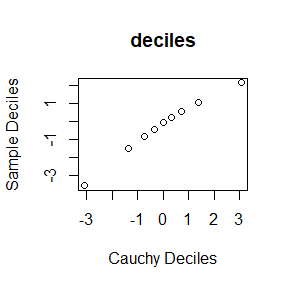

```r
qqplot(true_perc,mcmc_perc, main="deciles",xlab="Cauchy Deciles", ylab="Sample Deciles")
```

```r
set.seed(12345)


GXori<-c(1,0.1)

a<-2
b<-2
n<-10

GXfunc<-function(ori,N){
   GbN<-N
   GX<-matrix(0,ncol=GbN,nrow=2)
   GX[,1]<-ori
for(i in 2:GbN){
  x<-GX[,i-1][1]
  GX[,i][2]<-rbeta(1,shape1=x+a,shape2=n-x+b)
  y<-GX[,i][2]
  GX[,i][1]<-rbinom(1,size=n,prob=y)
}
  return(GX)
}
GX<-GXfunc(GXori,5000)
```

GX矩阵即为所得的二元分布的随机值。可以在Rmd文件中查看。  
2.For each of the above exercises, use the Gelman-Rubin method to monitor convergence of the chain, and run the chain until it converges approximately to the target distribution according to $\hat{R}<1.2$.

```r
set.seed(1543231221)

GRstat<-function(Cauchydata){
  n<-ncol(Cauchydata)#the length of every chain is n
  k<-nrow(Cauchydata)#k chains
  chainaver<-rowMeans(Cauchydata)
  allaver<-mean(chainaver)
  betweenvar<-n*sum((chainaver-allaver)^2)/(k-1)
  s<-numeric(n)
  ss<-numeric(k)
  for(i in 1:k){
    for(j in 1:n){
      s[j]<-(Cauchydata[i,j]-chainaver[i])^2
    }
    ss[i]<-mean(s)
  }
  withinvar<-mean(ss)
  VAR<-((n-1)*withinvar+betweenvar)/n
  R_hat<-sqrt(VAR/withinvar)
  return(R_hat)
}

x<-numeric(4)
x[1]<-rnorm(1,mean=1,sd=1)
x[2]<-rnorm(1,mean=2,sd=1)
x[3]<-rnorm(1,mean=3,sd=1)
x[4]<-rnorm(1,mean=4,sd=1)
experi<-10000
burn_in<-1000
Cdata<-matrix(0,ncol=experi,nrow=length(x))
for(i in 1:4){
  Cdata[i,]<-t(Cauchyfunc(x[i],experi))
}
Cdata1<-t(apply(Cdata, 1, cumsum))
   for (i in 1:nrow(Cdata))
       Cdata1[i,] <- Cdata[i,] / (1:ncol(Cdata))
Cdata<-Cdata1[,(burn_in+1):experi]
Cauchy_R_hat<-GRstat(Cdata)
print(Cauchy_R_hat)
r_hat <- rep(0, experi)
for (j in (burn_in+1):experi)
  r_hat[j] <- GRstat(Cdata1[,1:j])
plot(r_hat[(burn_in+1):experi], type="l", xlab="", ylab="R")
```

[output not shown]

```r
set.seed(123456)

gx<-matrix(0,ncol=4,nrow=2)
gx[,1]<-c(1,0.3)
gx[,2]<-c(2,0.2)
gx[,3]<-c(2,0.1)
gx[,4]<-c(1,0.1)

GbN<-10000
burn_in<-2000

GXdata1<-matrix(0,ncol=GbN,nrow=4)
GXdata2<-matrix(0,ncol=GbN,nrow=4)
for(i in 1:4){
  GXdata1[i,]<-GXfunc(gx[,i],GbN)[1,]
  GXdata2[i,]<-GXfunc(gx[,i],GbN)[2,]
}

GXdata1<-t(apply(GXdata1, 1, cumsum))
   for (i in 1:nrow(GXdata1))
       GXdata1[i,] <- GXdata1[i,] / (1:ncol(GXdata1))
GXdata2<-t(apply(GXdata2, 1, cumsum))
   for (i in 1:nrow(GXdata2))
       GXdata2[i,] <- GXdata2[i,] / (1:ncol(GXdata2))

GXdata11<-GXdata1[,(burn_in+1):GbN]
GXdata22<-GXdata2[,(burn_in+1):GbN]
GXVAR_x<-GRstat(GXdata11)
GXVAR_y<-GRstat(GXdata22)
print(paste('x:',GXVAR_x))
print(paste('y:',GXVAR_y))

GX_r_hat <- rep(0, GbN)
for (j in (burn_in+1):GbN)
  GX_r_hat[j] <- GRstat(GXdata1[,1:j])
plot(GX_r_hat[(burn_in+1):GbN], type="l", xlab="", ylab="R")
abline(h=1.2, lty=2)
for (j in (burn_in+1):GbN)
  GX_r_hat[j] <- GRstat(GXdata2[,1:j])
plot(GX_r_hat[(burn_in+1):GbN], type="l", xlab="", ylab="R")
abline(h=1.2, lty=2)
```

[output not shown]

## ANSWER

(1)Exercises 11.3:
(a) Write a function to compute the $k^{th}$ term in
$$\sum_{k=0}^{\infty}{\frac{(-1)^k}{k!2^k}\frac{{\Vert{a}\Vert}^{2k+2}}{(2k+1)(2k+2)}{\frac{\Gamma(\frac{d+1}{2})\Gamma(k+\frac{3}{2})}{\Gamma(k+\frac{d}{2}+1)}}}$$
where $d>1$ is an integer, a is a vector in $R^d$, and $\Vert·\Vert$ denotes the Euclidean norm. Perform the arithmetic so that the coefficients can be computed for (almost) arbitrarily large k and d. (This sum converges for all $a\in{R^d}$).
(b) Modify the function so that it computes and returns the sum.
(c) Evaluate the sum when $a=(1,2)^{T}$ .

```r
set.seed(1)
####(a)
JUAN<-function(k,a,d){

}

juan_k<-function(k,a,d){
  if((k<0)|(!k%%1==0)|(!d%%1==0)|(d<1)|(length(a)!=d)|(!is.vector(a)))
    {print("print invalid value")}
  else{
      a_length<-sqrt(a%*%a)
      a1<-(2*k+2)*log(a_length)
      a2<-lgamma((d+1)/2)
      a3<-lgamma(k+3/2)
      b1<-log(factorial(k))
      b2<-k*log(2)
      b3<-log(2*k+1)
      b4<-log(2*k+2)
      b5<-lgamma(k+d/2+1)
      res<-a1+a2+a3-b1-b2-b3-b4-b5
      if(k%%2==0){return(exp(res))}
      else{return(-exp(res))}
 }
}
####(b)
sum_juan_k<-function(k=0,a,d){
  if((k<0)|(!k%%1==0)|(!d%%1==0)|(d<1)|(length(a)!=d)|(!is.vector(a)))
  {print("print invalid value")}
  else{
    x_sum<-0
    resdu<-100

    while(abs(resdu)>1e-200){
      x<-juan_k(k=k,a=a,d=d)
      x_sum<-x_sum+x
      k<-k+1
      resdu<-x
    }
    return(x_sum)
    }
}
###(c)
a<-as.vector(c(1,2))
d<-length(a)
a_sum<-sum_juan_k(k=0,a,d=2)
print(a_sum)
```

```
##          [,1]
## [1,] 1.532164
```

最后计算出结果为1.53216399886164.
(1)Exercise 11.5:
Write a function to solve the equation:
$$\frac{2\Gamma(\frac{k}{2})}{\sqrt{\pi(k-1)}\Gamma(\frac{k-1}{2})}\int_{0}^{c_{k-1}}{(1+\frac{u^2}{k-1})^{-k/2}du}=\frac{2\Gamma(\frac{k+1}{2})}{\sqrt{\pi{k}}\Gamma(\frac{k}{2})}\int_{0}^{c_{k}}{(1+\frac{u^2}{k})^{-(k+1)/2}du}$$
for a, where
$$c_k=\sqrt{\frac{a^2{k}}{k+1-a^2}}$$
Compare the solutions with the points $A(k)$ in Exercise 11.4.

```r
set.seed(1)

in_func1<-function(u,m){
  (1+u^2/(m-1))^(-m/2)
}
happy_func<-function(k,a){

  l1<-log(2)+lgamma(k/2)
  l2<-0.5*log((pi*(k-1)))+lgamma((k-1)/2)
  c_k_1<-sqrt((a^2*(k-1))/(k-a^2))
  l3<-integrate(in_func1,rel.tol=.Machine$double.eps^0.25
,lower=0,upper=c_k_1,m=k)
  l3<-log(l3$value)
  y1<-exp(l1+l3-l2)
  return(y1)
}

solu_func<-function(k){
  output<-uniroot(function(a){happy_func(k,a)-happy_func(k+1,a)},lower=1,upper=2)
}

k_value<-c(4:25,100,500,1000)
roots<-numeric(length(k_value))
for(j in 1:length(k_value)){
  roots[j]<-solu_func(k_value[j])$root
}
table<-cbind(k_value,roots)
knitr::kable(table,align='c')
```

| k_value | roots |
| --- | --- |
| 4 | 1.492103 |
| 5 | 1.533556 |
| 6 | 1.562744 |
| 7 | 1.584430 |
| 8 | 1.601185 |
| 9 | 1.614521 |
| 10 | 1.625390 |
| 11 | 1.634419 |
| 12 | 1.642038 |
| 13 | 1.648554 |
| 14 | 1.654190 |
| 15 | 1.659114 |
| 16 | 1.663452 |
| 17 | 1.667304 |
| 18 | 1.670745 |
| 19 | 1.673840 |
| 20 | 1.676637 |
| 21 | 1.679178 |
| 22 | 1.681496 |
| 23 | 1.683620 |
| 24 | 1.685572 |
| 25 | 1.687373 |
| 100 | 1.720608 |
| 500 | 1.729756 |
| 1000 | 1.730907 |

```r
set.seed(1)
lambda2<-0.8
res<-1000
while(res>.Machine$double.eps^0.5){
  lambda1<-lambda2
  lambda2<-(3*(1+lambda1)+3.75)/10
  res<-lambda2-lambda1
}
print(lambda2)
```

```
## [1] 0.9642857
```

可以得出，收值为0.9642857,与分析所得0.96十分接近。  
—————————2021-11-25———————————–  
## QUESTION  
(1)Exercises 1 and 5 (page 204, Advanced R)  
(2)Excecises 1 and 7 (page 214, Advanced R)

## ANSWER

(1)Exercises 1:  
Why are the following two invocations of lapply() equivalent?  
trims<-c(0, 0.1, 0.2, 0.5)  
x<-rcauchy(100)  
lapply(trims, function(trim) mean(x, trim = trim))  
lapply(trims, mean, x = x)  
1)构造了一个函数，该函数将trims中的值作为参数代入，固定x，以输入参数为trim的值。lapply()就是将trims里的每一个值作为函数输入值计算一次；  
2)第二个lapply()函数直接利用了系统内的mean函数,并且固定x，则lapply自动将trims的每一个值识别为mean()函数中的trim参数的设定值。  
因此两种方法计算结果一致。  
(1)Exercises 5:  
For each model in the previous two exercises, extract $R^2$ using the function below.  
rsq <- function(mod) summary(mod)$r.squared

```r
###EXAMPLE 3
attach(mtcars)
formulas <- list(
  mpg ~ disp,
  mpg ~ I(1 / disp),
  mpg ~ disp + wt,
  mpg ~ I(1 / disp) + wt
)
lares<-lapply(formulas,function(x) lm(formula=x,data=mtcars))
##use function rsq and lapply to extract R^2
rsq <- function(mod) summary(mod)$r.squared
r_square1<-lapply(lares,rsq)
Formulas<-c('mpg ~ disp','mpg ~ I(1 / disp)','mpg ~ disp + wt','mpg ~ I(1 / disp) + wt')
#present the result in a table
table1<-cbind(Formulas,r_square1)
knitr::kable(table1,align='c')
```

| Formulas | r_square1 |
| --- | --- |
| mpg ~ disp | 0.71834334048973 |
| mpg ~ I(1 / disp) | 0.859686504658705 |
| mpg ~ disp + wt | 0.780930581659292 |
| mpg ~ I(1 / disp) + wt | 0.883803822574464 |

```r
###EXAMPLE 4
set.seed(1)
#use bootstrap to generate data
bootstraps <- lapply(1:10, function(i) {
  rows <- sample(1:nrow(mtcars), rep = TRUE)
  mtcars[rows, ]
})
#use lapply to extract R^2
whp<-lapply(bootstraps,function(x) lm(formula=mpg ~ disp,data=x))
r_square2<-lapply(whp,rsq)
#present the result in a table
table2<-cbind(r_square2)
knitr::kable(table2,align='c')
```

| r_square2 |
| --- |
| 0.549199841086178 |
| 0.680465054103738 |
| 0.694661230747723 |
| 0.79520215113681 |
| 0.80623611063048 |
| 0.805708289698806 |
| 0.806174767235794 |
| 0.694337822644918 |
| 0.604170524386881 |
| 0.610218206501082 |

(2)Excecises 1:  
Use vapply() to:  
a) Compute the standard deviation of every column in a numeric data frame.  
b) Compute the standard deviation of every numeric column in a mixed data frame. (Hint: you’ll need to use vapply() twice.)

```r
set.seed(1)
###a)
#generate a numeric data frame
orinumbers<-data.frame(x=runif(6,min=0,max=10),y=rnorm(6),z=rcauchy(6))
vapply(orinumbers,sd,FUN.VALUE=numeric(1))
```

```
##         x         y         z
## 3.1080905 0.7789181 1.5222968
```

```r
###b)
#generate a mixed data frame
oribnum<-data.frame(
  name=c('Anna','Cindy','Mike','Ross','Joey','Melody'),
  sex=c('F','F','M','M','M','F'),
  height=c(165.0,170.5,188.3,190.1,183.0,174.2),
  weight=c(50.5,56.3,68.0,75.1,65.9,55.4)
  )
#use is.numeric() to identify numerical data
resb<-vapply(oribnum,is.numeric,FUN.VALUE=logical(1))
#use vapply to compute the standard deviation of numerical columns
vapply(oribnum[resb],sd,FUN.VALUE=numeric(1))
```

```
##    height    weight
## 10.154687  9.284539
```

(2)Excecises 7:  
Implement mcsapply(), a multicore version of sapply(). Can you implement mcvapply(),a parallel version of vapply()? Why or why not?

```r
set.seed(1)
library(parallel)
#Calculate the number of computer cores
cores <- detectCores(logical = FALSE)

#use parSapply in parallel to generate mcsapply
mcsapply<-function(x,f){
  coresnum<- makeCluster(3)
  median_res<-parSapply(coresnum,x,f)
  stopCluster(coresnum)
  return(median_res)
}

ttestdata<-replicate(10000,t.test(rnorm(20,1,11), runif(30)),simplify=FALSE)
system.time(mcsapply(ttestdata,function(x) unlist(x)))
system.time(sapply(ttestdata,function(x) unlist(x)))
```

[output not shown]

Write an Rcpp function for Exercise 9.8 (page 278, Statistical Computing with R).  
Compare the corresponding generated random numbers with pure R language using the function “qqplot”.  
Campare the computation time of the two functions with the function “microbenchmark”.  
Comments your results.

## ANSWER

Exercise 9.8:This example appears in [40]. Consider the bivariate density
$$f(x,y)\propto{C_{n}^{x}y^{x+a-1}(1-y)^{n-x+b-1},x=0,1,…,n,0\leq{y}\leq{1}}$$
It can be shown (see e.g. [23]) that for fixed $a,b,n$, the conditional distributions are $Binomial(n,y)$ and $Beta(x+a,n-x+b)$. Use the Gibbs sampler to generate a chain with target joint density f(x,y).

```r
set.seed(1)
library(Rcpp)
cppFunction(
'NumericMatrix Mygibbs(double x,double y,int N) {
  NumericMatrix GX(2,N);
  int a=2,b=2,n=10;
  GX(0,0)=x;
  GX(1,0)=y;
  for(int i=1;i<N;i++){
    double x0=GX(0,i-1);
    GX(1,i)=rbeta(1,x0+a,n-x0+b)[0];
    double y0=GX(1,i);
    GX(0,i)=rbinom(1,n,y0)[0];
  }
  return GX;
}')
GX_cpp<-Mygibbs(1,0.1,1000)

GXfunc<-function(ori,N){
   GbN<-N
   GX<-matrix(0,ncol=GbN,nrow=2)
   GX[,1]<-ori
for(i in 2:GbN){
  x<-GX[,i-1][1]
  GX[,i][2]<-rbeta(1,shape1=x+a,shape2=n-x+b)
  y<-GX[,i][2]
  GX[,i][1]<-rbinom(1,size=n,prob=y)
}
  return(GX)
}
a<-2
b<-2
n<-10
GXori<-c(1,0.1)
GX_r<-GXfunc(GXori,1000)

qqplot(GX_cpp[1,],GX_r[1,])
qqplot(GX_cpp[2,],GX_r[2,])
```

[output not shown]

```r
set.seed(1)
library(microbenchmark)
ts <- microbenchmark(Gibbs1=Mygibbs(1,0.1,1000),Gibbs2=GXfunc(GXori,1000))
summary(ts)[,c(1,3,5,6)]
```

[output not shown]